# 03_QuantLing_Section

Eric Wilbanks

2/07/2020 - 2/10/2020

## 1. Goals for Section

- remaining data frame points
- loading/saving data
- visualization with ggplot2

## 2. Data Frame Errata

Another useful operator is the `%in%` operator. This can be more efficient that many chained `or` statements.

```r
library(languageR)
data(sizeRatings)
fruits <- sizeRatings[sizeRatings$Word %in% c('cherry','lemon','pear','blackberry'),]
```

We can also create new factors! In the code below, we add a new factor which has a value of `familiar` if `sizeRatings$MeanFamiliarity` is greater than 0.7, and `unfamiliar` if not.

```r
sizeRatings$binary_MF <- ifelse(sizeRatings$MeanFamiliarity > 0.7, 'familiar', 'unfamiliar')
```

```
What differences are there between $Language and $binary_MF when you call str(sizeRatings) ?
```

## 3. Loading and saving dataframes

A common format for data is `.csv`, (“comma separated values”).

```
Download the `PresuppositionType_data.csv` file from bCourses.

What does this file look like if you open it in a text editor?
```

### 3.1 Reading in Data Frame

```r
presup <- read.csv(file.choose())
```

You can also specify the path to the file if you have that information. This is always specified relative to your working path.

```
What is a working path?
```

```r
presup <- read.csv('PresuppositionType_data.csv')
```

You can query your current working directory if you’re not sure, and can set it to a specific directory. You can also permanently change your working directory in RStudio using **Tools > Global Options**

```r
getwd()
```

```
## [1] "/home/eric/Documents/Teaching/s20_LING160/materials"
```

```r
#setwd('/home/eric/TotallyRealFolder')
```

### 3.2 Saving a data frame (as csv)

```r
sub <- presup[1:20,]
write.csv(sub, file = 'new_df.csv',row.names=F)
write.csv(sub, file = 'new_df_test.csv', row.names=T) # default option for row.names; what's changed?
```

## 4. Visualization with ggplot2

There are various ways to make visualizations in R. We’ll be using a powerful and well documented package, `ggplot2`.

```r
# install the package (if you haven't ever done this)
#install.packages('ggplot2')

# load the packages we'll need
library(ggplot2)

# load the Dutch ge- data
data(durationsGe)
```

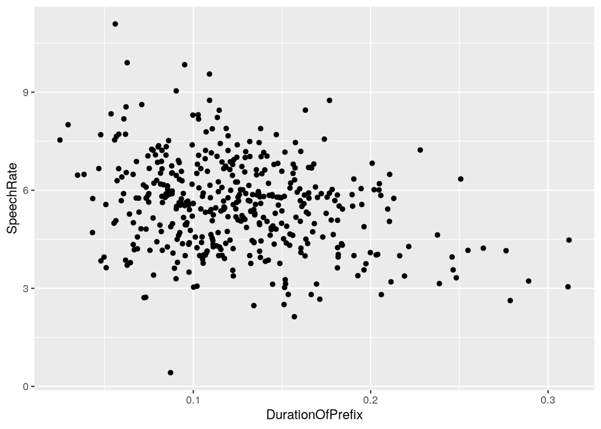

```r
# simple scatter-plot
ggplot(durationsGe, aes(DurationOfPrefix,SpeechRate)) + geom_point()
```

The first part of the command `ggplot(durationsGe, aes(DurationOfPrefix,SpeechRate))` establishes the data that’s being used and which factors are mapped to the x and y dimensions.

The second part `+ geom_point()` adds a geom to the graph. You can have multiple geoms that layer on the same plot.

```
Trying adding geom_smooth(method='lm') to the plot you just made.
```

You can change the labels of various elements by creating a label layer, using `labs()`

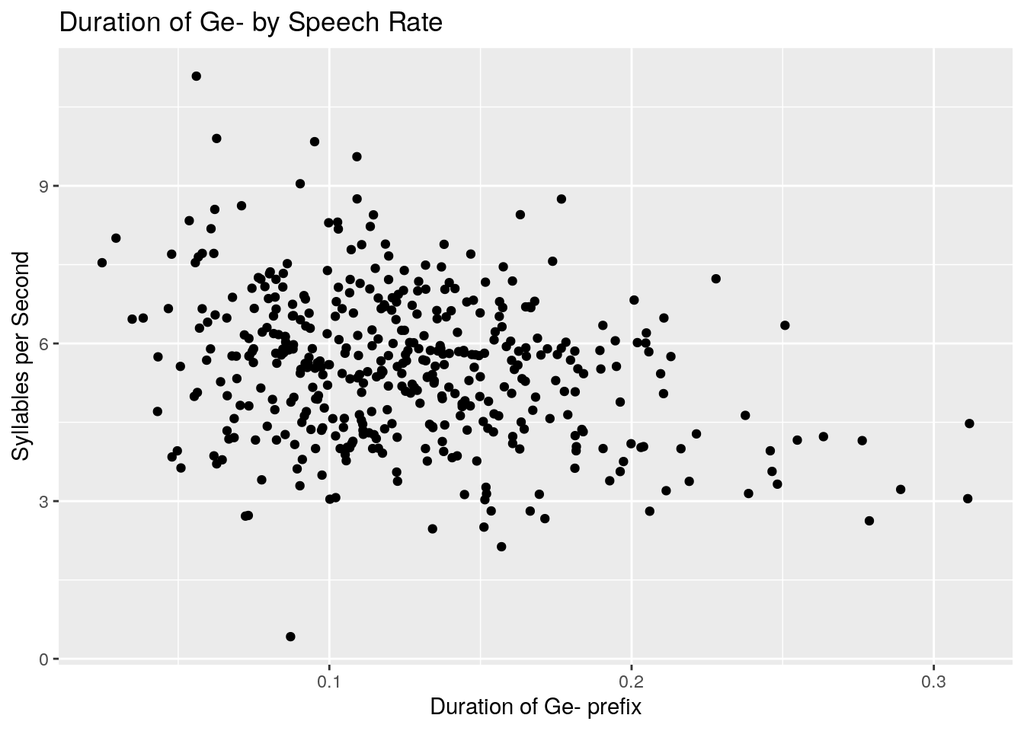

```r
ggplot(durationsGe, aes(DurationOfPrefix,SpeechRate)) + geom_point() + labs(x='Duration of Ge- prefix', y='Syllables per Second', title='Duration of Ge- by Speech Rate')
```

Let’s try a basic density plot

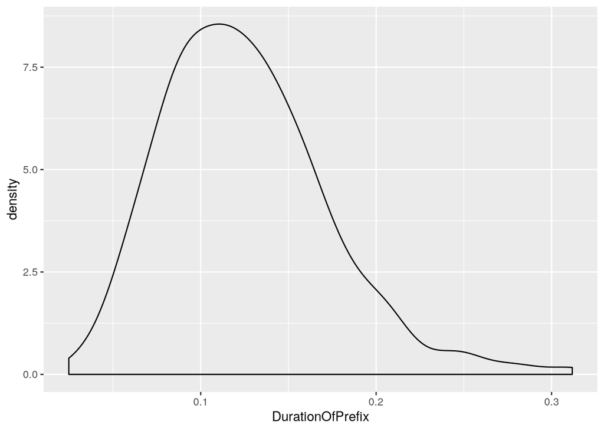

```r
ggplot(durationsGe, aes(DurationOfPrefix)) + geom_density()
```

We can also use other factors that aren’t x or y dimensions to break down the data:

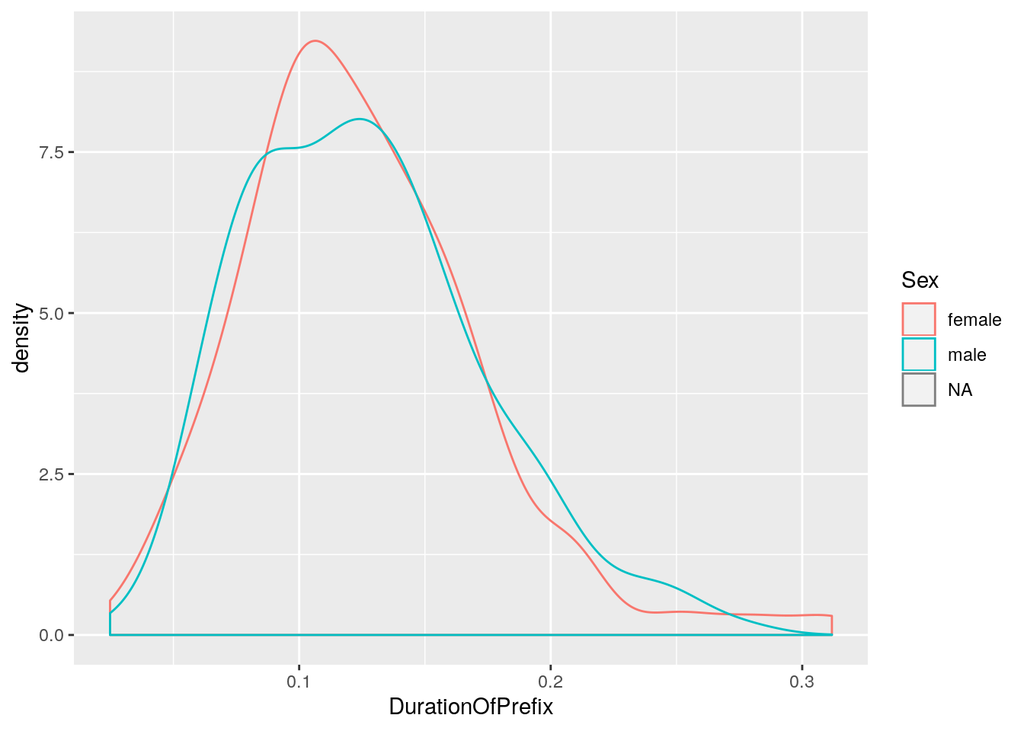

```
What happens when you replace `color` with `lty`?, `fill`?
```

```r
ggplot(durationsGe, aes(DurationOfPrefix, color=Sex)) + geom_density()
```

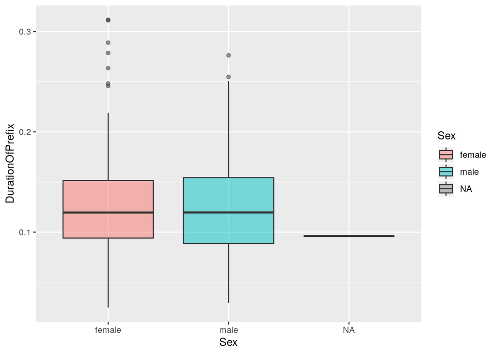

```
What is the third box-plot?

Find which row(s) of the data-frame are responsible for this third plot. Create a sub-set of the data-frame that avoids this issue, and recreate the plot.
```

```r
# basic box-plot
ggplot(durationsGe, aes(Sex,DurationOfPrefix, fill=Sex)) + geom_boxplot(alpha=0.5)
```

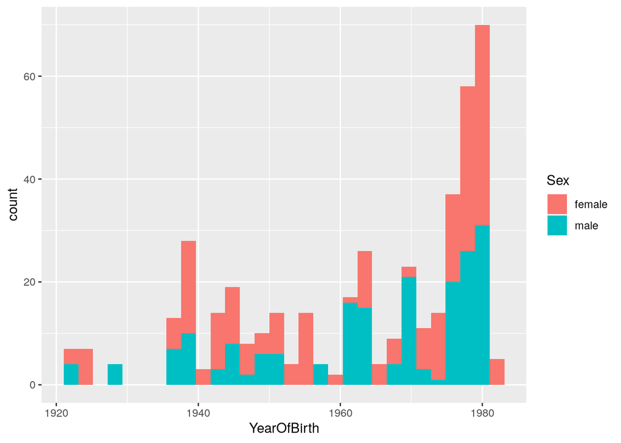

```
What does this plot correspond to?

What happens when we add facet_grid(~Sex) to the plot? What if we add facet_grid(Sex~.) instead?

Create an equivalent density plot and consider how it compares to the histogram.
```

```r
# basic histogram
ggplot(durationsGe, aes(YearOfBirth,fill=Sex)) + geom_histogram()
```

## 4. Plot Extensions

```
Let's begin by creating the following plots using the durationsGe dataframe:

1. A scatterplot which shows the relationship between year of birth and speech rate, with a facet by speaker sex.
2. A boxplot of Ge- duration, with an x-axis and fill of NumberSegmentsOnset and custom axis and title labels.
3. A scatterplot of Ge- duration by log() transformed Ge-duration
4. Create a new factor of binary Frequency. ('low' if durationsGe$Frequency is less than the mean of this factor, 'high' if else.). Using this new factor, create a scatterplot of speech rate by ge- duration, faceted by binary frequency.
```